# Task 4: Discover Associations Between Products

This notebook contains the answers to Task 4: Discover Associations Between Products.

```r
#library(readr)
library(caret)

#library(corrplot)

library(arules)
library(arulesViz)

library(tidyverse)
library(readxl)
library(knitr)
library(ggplot2)
library(lubridate)
library(plyr)


library(gbm)
library(Rcpp)
```

The transaction dataset required for this task has been sent by Blackwell. Below we will import that data into R:

```r
tr <- read.transactions('ElectronidexTransactions2017.csv', format = 'basket', sep=',')
```

```
removing duplicated items in transactions
```

```r
tr
```

```
transactions in sparse format with
 9835 transactions (rows) and
 125 items (columns)
```

The above function removes appearing twice or more in the same transaction. It does not remove duplicated transactions, thus, for the purpose of our analysis, all is fine.

```r
inspect(tr[0:10]) # See the first N transactions.
```

```
     items
[1]  {Acer Aspire,
      Belkin Mouse Pad,
      Brother Printer Toner,
      VGA Monitor Cable}
[2]  {Apple Wireless Keyboard,
      Dell Desktop,
      Lenovo Desktop Computer}
[3]  {iMac}
[4]  {Acer Desktop,
      Intel Desktop,
      Lenovo Desktop Computer,
      XIBERIA Gaming Headset}
[5]  {ASUS Desktop,
      Epson Black Ink,
      HP Laptop,
      iMac}
[6]  {ASUS Monitor,
      Gaming Mouse Professional,
      iMac,
      Lenovo Desktop Computer,
      Mackie CR Speakers}
[7]  {CYBERPOWER Gamer Desktop}
[8]  {Apple MacBook Air,
      Bose Companion Speakers,
      CYBERPOWER Gamer Desktop,
      HP Laptop,
      Large Mouse Pad}
[9]  {Logitech Keyboard}
[10] {Generic Black 3-Button,
      iMac}
```

```r
#OR
LIST(tr[0:10]) # Lists the transactions by conversion (LIST must be capitalized)
```

```
[[1]]
[1] "Acer Aspire"           "Belkin Mouse Pad"      "Brother Printer Toner" "VGA Monitor Cable"

[[2]]
[1] "Apple Wireless Keyboard" "Dell Desktop"            "Lenovo Desktop Computer"

[[3]]
[1] "iMac"

[[4]]
[1] "Acer Desktop"            "Intel Desktop"           "Lenovo Desktop Computer" "XIBERIA Gaming Headset"

[[5]]
[1] "ASUS Desktop"    "Epson Black Ink" "HP Laptop"       "iMac"

[[6]]
[1] "ASUS Monitor"              "Gaming Mouse Professional" "iMac"                      "Lenovo Desktop Computer"
[5] "Mackie CR Speakers"

[[7]]
[1] "CYBERPOWER Gamer Desktop"

[[8]]
[1] "Apple MacBook Air"        "Bose Companion Speakers"  "CYBERPOWER Gamer Desktop" "HP Laptop"
[5] "Large Mouse Pad"

[[9]]
[1] "Logitech Keyboard"

[[10]]
[1] "Generic Black 3-Button" "iMac"
```

```r
length(tr)
```

```
[1] 9835
```

```r
table(size(tr))
```

```
   0    1    2    3    4    5    6    7    8    9   10   11   12   13   14   15   16   17   18   19   20   21   22   23   25   26
   2 2163 1647 1294 1021  856  646  540  439  353  247  171  119   77   72   56   41   26   20   10   10   10    5    3    1    1
  27   29   30
   3    1    1
```

Note that we have two transactions without any purchased item. These will be removed:

```r
tr <- tr[which(size(tr) != 0)]
table(size(tr))
```

```
   1    2    3    4    5    6    7    8    9   10   11   12   13   14   15   16   17   18   19   20   21   22   23   25   26   27
2163 1647 1294 1021  856  646  540  439  353  247  171  119   77   72   56   41   26   20   10   10   10    5    3    1    1    3
  29   30
   1    1
```

Done! Dataset is clean(er) now.

```r
itemLabels(tr)
```

```
  [1] "1TB Portable External Hard Drive"                      "2TB Portable External Hard Drive"
  [3] "3-Button Mouse"                                        "3TB Portable External Hard Drive"
  [5] "5TB Desktop Hard Drive"                                "Acer Aspire"
  [7] "Acer Desktop"                                          "Acer Monitor"
  [9] "Ailihen Stereo Headphones"                             "Alienware Laptop"
 [11] "AOC Monitor"                                           "APIE Bluetooth Headphone"
 [13] "Apple Earpods"                                         "Apple MacBook Air"
 [15] "Apple MacBook Pro"                                     "Apple Magic Keyboard"
 [17] "Apple TV"                                              "Apple Wired Keyboard"
 [19] "Apple Wireless Keyboard"                               "ASUS 2 Monitor"
 [21] "ASUS Chromebook"                                       "ASUS Desktop"
 [23] "ASUS Monitor"                                          "Audio Cable"
 [25] "Backlit LED Gaming Keyboard"                           "Belkin Mouse Pad"
 [27] "Bose Companion Speakers"                               "Brother Printer"
 [29] "Brother Printer Toner"                                 "Cambridge Bluetooth Speaker"
```

[output cut: 48 more lines]

As mentioned in the PoA, the dataset contains 125 different items.

```r
summary(tr)
```

```
transactions as itemMatrix in sparse format with
 9833 rows (elements/itemsets/transactions) and
 125 columns (items) and a density of 0.03506885

most frequent items:
                    iMac                HP Laptop CYBERPOWER Gamer Desktop            Apple Earpods        Apple MacBook Air
                    2519                     1909                     1809                     1715                     1530
                 (Other)
                   33622

element (itemset/transaction) length distribution:
sizes
   1    2    3    4    5    6    7    8    9   10   11   12   13   14   15   16   17   18   19   20   21   22   23   25   26   27
2163 1647 1294 1021  856  646  540  439  353  247  171  119   77   72   56   41   26   20   10   10   10    5    3    1    1    3
  29   30
   1    1

   Min. 1st Qu.  Median    Mean 3rd Qu.    Max.
  1.000   2.000   3.000   4.384   6.000  30.000

includes extended item information - examples:
```

|  | labels |
| --- | --- |
| 1 | 1TB Portable External Hard Drive |
| 2 | 2TB Portable External Hard Drive |
| 3 | 3-Button Mouse |

Looking at the summary above, the following takeaways can be taken: -Blackwell has given us 9835 transactions to analyze and 125 items (columns) can be puchased. -The density is 0.035 meaning that a total of 9835 x 125 x 0.035 = 43104 items have been purchased in total. This can be confirmed by adding up the most frequent items. - The most puchased items are (this can be visualized in the plot created with itemFrequencyPlot below): 1. *iMac* with 2519 purchases; 2. *HP Laptop* with 1909 purchases; 3. *CYBERPOWER Gamer Desktop* with 1809 purchases; 4. *Apple Earpods* with 1715 purchases; 5. *Apple MacBook Air* with 1530 purchases.

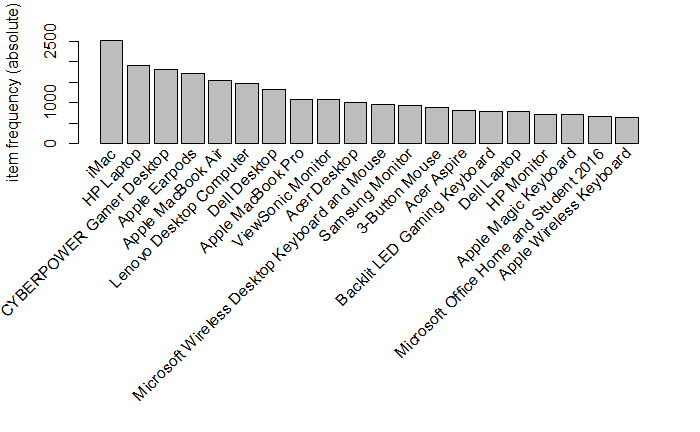

```r
itemFrequencyPlot(tr, topN=20, type='absolute')
```

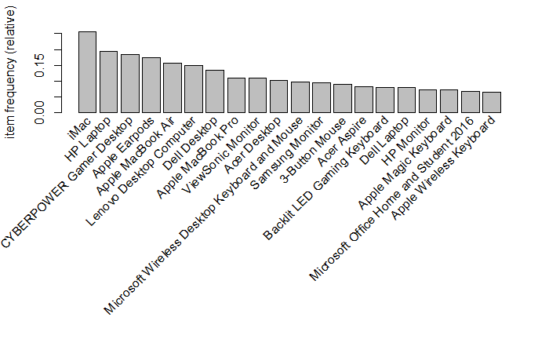

```r
itemFrequencyPlot(tr, topN=20, type='relative')
```

- Looking at the size of the transactions: (2 transactions were for 0 items, these have been cleaned), 2163 transactions were for just 1 item, 1647 transactions for 2 items, all the way up to the biggest transaction: 1 transaction for 30 items. This indicates that most customers buy a small number of items in each transaction. -Additionally the size of purchases seems right skewed (as the mean is larger than the median an as can be seen below in the barplot of the table of transaction sizes) as can be seen below:

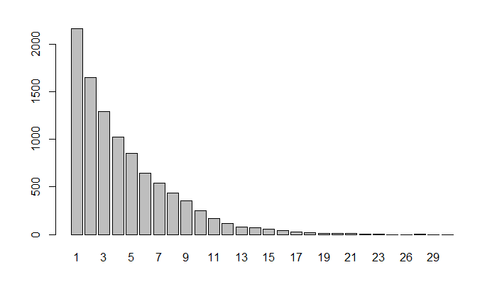

```r
barplot(table(size(tr)))
```

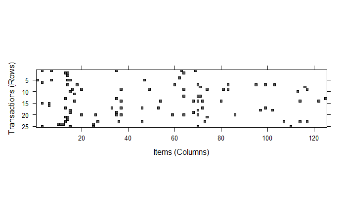

```r
image(sample(tr, 25))
```

The graph above shows which items are more frequently purchased. There is a dense zone in between items 60 and 80. This seems to be the Apple products that begin with the letter ‘i’.

*Use Apriori algorithm to discover any relationships between the items within the Electronidex’s transactions*

“The Apriori algorithm is helpful when working with large datasets and is used to uncover insights pertaining to transactional datasets. It is based on item frequency. The Apriori algorithm assesses association rules using two types of measurements. The first statistical measure is the Support measurement, which measures itemsets or rules frequency within your transactional data.The second statistical measure is the Confidence measurement, which measures the accuracy of the rules. A rule that measures high in both support and confidence is known as a strong rule.”

The suggested parameters are requesting that the rules cover 10% of the transactions (the dataset is quite large, therefore the original 10% ~983 rows is a lot for this purpose) and are 80% correct. With these parameters no rules are found, because this shop offers a wide range of items and repetitions are not found too often. In order to catch any rule, I reduced the support to 1% and the confidence to 30%.

```r
rules <- apriori(tr, parameter = list(supp=0.01, conf=0.3,minlen=2))
```

```
Apriori

Parameter specification:
```

|  | confidence | minval | smax | arem | aval | originalSupport | maxtime | support | minlen | maxlen | target | ext |
| --- | --- | --- | --- | --- | --- | --- | --- | --- | --- | --- | --- | --- |
|  | 0.3 | 0.1 | 1 | none | FALSE | TRUE | 5 | 0.01 | 2 | 10 | rules | TRUE |

```
Algorithmic control:
```

|  | filter | tree | heap | memopt | load | sort | verbose |
| --- | --- | --- | --- | --- | --- | --- | --- |
|  | 0.1 | TRUE | TRUE | FALSE | TRUE | 2 | TRUE |

```
Absolute minimum support count: 98

set item appearances ...[0 item(s)] done [0.00s].
set transactions ...[125 item(s), 9833 transaction(s)] done [0.00s].
sorting and recoding items ... [82 item(s)] done [0.00s].
creating transaction tree ... done [0.00s].
checking subsets of size 1 2 3 4 done [0.00s].
writing ... [154 rule(s)] done [0.00s].
creating S4 object  ... done [0.00s].
```

```r
rules <- sort(rules, by='confidence', decreasing = TRUE)
summary(rules)
```

```
set of 154 rules

rule length distribution (lhs + rhs):sizes
 2  3
72 82

   Min. 1st Qu.  Median    Mean 3rd Qu.    Max.
  2.000   2.000   3.000   2.532   3.000   3.000

summary of quality measures:
    support          confidence        coverage            lift           count
 Min.   :0.01007   Min.   :0.3040   Min.   :0.01739   Min.   :1.204   Min.   : 99.0
 1st Qu.:0.01109   1st Qu.:0.3383   1st Qu.:0.02815   1st Qu.:1.619   1st Qu.:109.0
 Median :0.01459   Median :0.3895   Median :0.03656   Median :1.885   Median :143.5
 Mean   :0.01828   Mean   :0.4033   Mean   :0.04746   Mean   :1.944   Mean   :179.8
 3rd Qu.:0.02125   3rd Qu.:0.4481   3rd Qu.:0.05743   3rd Qu.:2.232   3rd Qu.:209.0
 Max.   :0.07556   Max.   :0.6023   Max.   :0.19414   Max.   :3.359   Max.   :743.0

mining info:
```

|  | data | ntransactions | support | confidence | call |
| --- | --- | --- | --- | --- | --- |
|  | tr | 9833 | 0.01 | 0.3 | apriori(data = tr, parameter = list(supp = 0.01, conf = 0.3, minlen = 2)) |

Note: Apriori only creates rules with one item in the RHS (Consequent)! The default value in ’>APparameter for minlen is 1. This means that rules with only one item (i.e., an empty antecedent/LHS) like {} => {beer} will be created. These rules mean that no matter what other items are involved, the item in the RHS will appear with the probability given by the rule’s confidence (which equals the support). In order to avoid these rules I used the argument parameter=list(minlen=2).

Before going into any further detail, it is important to understand what each metric of the apriori algorithm means: **Support**: This says how popular an itemset is, as measured by the proportion of transactions in which an itemset appears. - Support{X} = Number Of X in transaction/Number of total transactions; **Coverage**: THis metric is simillar to the support metric except for the fact that it only takes into account the LHS of the transaction rule. Therefore, this metric is always larger (or equal if this combination is only purchased with the RHS of the rule included) than the support. **Confidence**: This says how likely item Y is purchased when item X is purchased, expressed as {X -> Y}. This is measured by the proportion of transactions with item X, in which item Y also appears. - Confidence{X->Y} = Support{X,Y}/Support{X} **Lift**: This says how likely item Y is purchased when item X is purchased, while controlling for how popular item Y is. A lift of 1 implies no association between items. A lift value greater than 1 means that item Y is likely to be bought if item X is bought, while a value lower than 1 means that item Y is unlikekly to be bought is item X is bought: - Lift(X->Y) = Support{X,Y}/(Support{X}*Support{Y})

```r
inspect(rules)
```

|  | lhs |  | rhs | support | confidence | coverage | lift | count |
| --- | --- | --- | --- | --- | --- | --- | --- | --- |
| [1] | {Acer Aspire, ViewSonic Monitor} | => | {HP Laptop} | 0.01078003 | 0.6022727 | 0.01789891 | 3.102225 | 106 |
| [2] | {ASUS 2 Monitor, Lenovo Desktop Computer} | => | {iMac} | 0.01088172 | 0.5911602 | 0.01840740 | 2.307614 | 107 |
| [3] | {Apple Magic Keyboard, Dell Desktop} | => | {iMac} | 0.01016984 | 0.5847953 | 0.01739042 | 2.282768 | 100 |
| [4] | {ASUS Monitor, HP Laptop} | => | {iMac} | 0.01179701 | 0.5829146 | 0.02023797 | 2.275426 | 116 |
| [5] | {ASUS 2 Monitor, HP Laptop} | => | {iMac} | 0.01108512 | 0.5828877 | 0.01901759 | 2.275321 | 109 |
| [6] | {Dell Desktop, ViewSonic Monitor} | => | {HP Laptop} | 0.01525475 | 0.5747126 | 0.02654327 | 2.960267 | 150 |
| [7] | {Dell Desktop, ViewSonic Monitor} | => | {iMac} | 0.01474626 | 0.5555556 | 0.02654327 | 2.168630 | 145 |
| [8] | {Lenovo Desktop Computer, ViewSonic Monitor} | => | {iMac} | 0.01576325 | 0.5555556 | 0.02837384 | 2.168630 | 155 |
| [9] | {HP Laptop, Microsoft Office Home and Student 2016} | => | {iMac} | 0.01291569 | 0.5521739 | 0.02339062 | 2.155429 | 127 |
| [10] | {Acer Desktop, ViewSonic Monitor} | => | {iMac} | 0.01006814 | 0.5439560 | 0.01850910 | 2.123350 | 99 |

[output cut: 144 more lines]

```r
#inspect(rules[1:10])
```

*Sort model according to different metrics in order to improve the results:*

Above the model was sort according to the confidence, therefore I will not repeat the same inspection. I will move on to support.

```r
inspect(sort(rules, by = "support"))
```

|  | lhs |  | rhs | support | confidence | coverage | lift | count |
| --- | --- | --- | --- | --- | --- | --- | --- | --- |
| [1] | {HP Laptop} | => | {iMac} | 0.07556188 | 0.3892090 | 0.19414217 | 1.519290 | 743 |
| [2] | {Lenovo Desktop Computer} | => | {iMac} | 0.05878165 | 0.3969780 | 0.14807282 | 1.549617 | 578 |
| [3] | {CYBERPOWER Gamer Desktop} | => | {iMac} | 0.05674769 | 0.3084577 | 0.18397234 | 1.204075 | 558 |
| [4] | {Dell Desktop} | => | {iMac} | 0.05461202 | 0.4074355 | 0.13403844 | 1.590438 | 537 |
| [5] | {ViewSonic Monitor} | => | {iMac} | 0.04942540 | 0.4479263 | 0.11034272 | 1.748495 | 486 |
| [6] | {ViewSonic Monitor} | => | {HP Laptop} | 0.04800163 | 0.4350230 | 0.11034272 | 2.240745 | 472 |
| [7] | {Lenovo Desktop Computer} | => | {HP Laptop} | 0.04617106 | 0.3118132 | 0.14807282 | 1.606107 | 454 |
| [8] | {Dell Desktop} | => | {HP Laptop} | 0.04495068 | 0.3353566 | 0.13403844 | 1.727376 | 442 |
| [9] | {Acer Desktop} | => | {iMac} | 0.03640801 | 0.3572854 | 0.10190176 | 1.394676 | 358 |
| [10] | {Apple MacBook Pro} | => | {iMac} | 0.03447574 | 0.3118675 | 0.11054612 | 1.217385 | 339 |

[output cut: 144 more lines]

The rule with the highest support has got 7.5%. This metric on its own is not robust. We have to look into the confidence and lift in order to get a better understanding. Anyhow, these are the transactions that were most often verified, and therefore will probably be more relevant towards the majority of clients. Just to verify, the order of the rules sorted according to count are in fact the same as the support. This makes sense as support is nothing else but the count of how many times a rule is verified divided by the total amount of transactions.

```r
#inspect(sort(rules, by = "count"))
```

The transaction rules could be additionally sorted according to the remaining metrics.

```r
inspect(sort(rules, by = "lift"))
```

|  | lhs |  | rhs | support | confidence | coverage | lift | count |
| --- | --- | --- | --- | --- | --- | --- | --- | --- |
| [1] | {Acer Aspire, HP Laptop} | => | {ViewSonic Monitor} | 0.01078003 | 0.3706294 | 0.02908573 | 3.358893 | 106 |
| [2] | {Acer Aspire, ViewSonic Monitor} | => | {HP Laptop} | 0.01078003 | 0.6022727 | 0.01789891 | 3.102225 | 106 |
| [3] | {Dell Desktop, HP Laptop} | => | {ViewSonic Monitor} | 0.01525475 | 0.3393665 | 0.04495068 | 3.075568 | 150 |
| [4] | {ASUS Chromebook} | => | {ViewSonic Monitor} | 0.01749212 | 0.3333333 | 0.05247636 | 3.020891 | 172 |
| [5] | {Acer Desktop, HP Laptop} | => | {Dell Desktop} | 0.01240720 | 0.3973941 | 0.03122140 | 2.964777 | 122 |
| [6] | {Dell Desktop, ViewSonic Monitor} | => | {HP Laptop} | 0.01525475 | 0.5747126 | 0.02654327 | 2.960267 | 150 |
| [7] | {Acer Aspire, HP Laptop} | => | {Dell Desktop} | 0.01108512 | 0.3811189 | 0.02908573 | 2.843355 | 109 |
| [8] | {HP Laptop, iMac} | => | {ViewSonic Monitor} | 0.02369572 | 0.3135935 | 0.07556188 | 2.841996 | 233 |
| [9] | {HP Laptop, Lenovo Desktop Computer} | => | {ViewSonic Monitor} | 0.01403437 | 0.3039648 | 0.04617106 | 2.754733 | 138 |
| [10] | {Acer Aspire, iMac} | => | {Dell Desktop} | 0.01108512 | 0.3609272 | 0.03071291 | 2.692714 | 109 |

[output cut: 142 more lines]

```r
inspect(sort(rules, by = "coverage"))
```

|  | lhs |  | rhs | support | confidence | coverage | lift | count |
| --- | --- | --- | --- | --- | --- | --- | --- | --- |
| [1] | {HP Laptop} | => | {iMac} | 0.07556188 | 0.3892090 | 0.19414217 | 1.519290 | 743 |
| [2] | {CYBERPOWER Gamer Desktop} | => | {iMac} | 0.05674769 | 0.3084577 | 0.18397234 | 1.204075 | 558 |
| [3] | {Lenovo Desktop Computer} | => | {iMac} | 0.05878165 | 0.3969780 | 0.14807282 | 1.549617 | 578 |
| [4] | {Lenovo Desktop Computer} | => | {HP Laptop} | 0.04617106 | 0.3118132 | 0.14807282 | 1.606107 | 454 |
| [5] | {Dell Desktop} | => | {iMac} | 0.05461202 | 0.4074355 | 0.13403844 | 1.590438 | 537 |
| [6] | {Dell Desktop} | => | {HP Laptop} | 0.04495068 | 0.3353566 | 0.13403844 | 1.727376 | 442 |
| [7] | {Apple MacBook Pro} | => | {iMac} | 0.03447574 | 0.3118675 | 0.11054612 | 1.217385 | 339 |
| [8] | {ViewSonic Monitor} | => | {HP Laptop} | 0.04800163 | 0.4350230 | 0.11034272 | 2.240745 | 472 |
| [9] | {ViewSonic Monitor} | => | {iMac} | 0.04942540 | 0.4479263 | 0.11034272 | 1.748495 | 486 |
| [10] | {Acer Desktop} | => | {iMac} | 0.03640801 | 0.3572854 | 0.10190176 | 1.394676 | 358 |

[output cut: 142 more lines]

Redundant rules should be discarded to reduce the complexity of the model. Redundant rules are equivalent to a negative or zero improvement as defined by Bayardo et al. (2000). Now, verify if any rule is redundant:

```r
is.redundant(rules)
```

```
  [1] FALSE FALSE FALSE FALSE FALSE FALSE FALSE FALSE FALSE FALSE FALSE FALSE FALSE FALSE FALSE FALSE FALSE FALSE FALSE FALSE FALSE
 [22] FALSE FALSE FALSE FALSE FALSE FALSE FALSE FALSE FALSE FALSE FALSE FALSE FALSE FALSE FALSE FALSE FALSE FALSE FALSE FALSE FALSE
 [43] FALSE FALSE FALSE FALSE FALSE FALSE FALSE FALSE FALSE FALSE FALSE FALSE FALSE FALSE FALSE FALSE FALSE FALSE FALSE FALSE FALSE
 [64] FALSE FALSE FALSE FALSE FALSE FALSE FALSE FALSE FALSE FALSE FALSE FALSE FALSE FALSE FALSE FALSE FALSE FALSE FALSE FALSE FALSE
 [85]  TRUE FALSE FALSE FALSE  TRUE FALSE FALSE FALSE FALSE FALSE FALSE FALSE FALSE FALSE FALSE FALSE FALSE FALSE FALSE FALSE FALSE
[106] FALSE FALSE FALSE FALSE FALSE FALSE FALSE FALSE FALSE FALSE FALSE FALSE FALSE FALSE FALSE FALSE FALSE FALSE FALSE FALSE FALSE
[127] FALSE FALSE FALSE FALSE FALSE FALSE FALSE FALSE FALSE FALSE FALSE FALSE FALSE FALSE FALSE FALSE FALSE FALSE FALSE FALSE FALSE
[148] FALSE FALSE FALSE FALSE FALSE FALSE FALSE
```

```r
redundant <- which(is.redundant(rules))
redundant
```

```
[1] 85 89
```

Only two rules are redundant, remove them to reduce entropy of this model and analysis.

```r
rules <- rules[-redundant]

inspect(rules)
```

|  | lhs |  | rhs | support | confidence | coverage | lift | count |
| --- | --- | --- | --- | --- | --- | --- | --- | --- |
| [1] | {Acer Aspire, ViewSonic Monitor} | => | {HP Laptop} | 0.01078003 | 0.6022727 | 0.01789891 | 3.102225 | 106 |
| [2] | {ASUS 2 Monitor, Lenovo Desktop Computer} | => | {iMac} | 0.01088172 | 0.5911602 | 0.01840740 | 2.307614 | 107 |
| [3] | {Apple Magic Keyboard, Dell Desktop} | => | {iMac} | 0.01016984 | 0.5847953 | 0.01739042 | 2.282768 | 100 |
| [4] | {ASUS Monitor, HP Laptop} | => | {iMac} | 0.01179701 | 0.5829146 | 0.02023797 | 2.275426 | 116 |
| [5] | {ASUS 2 Monitor, HP Laptop} | => | {iMac} | 0.01108512 | 0.5828877 | 0.01901759 | 2.275321 | 109 |
| [6] | {Dell Desktop, ViewSonic Monitor} | => | {HP Laptop} | 0.01525475 | 0.5747126 | 0.02654327 | 2.960267 | 150 |
| [7] | {Dell Desktop, ViewSonic Monitor} | => | {iMac} | 0.01474626 | 0.5555556 | 0.02654327 | 2.168630 | 145 |
| [8] | {Lenovo Desktop Computer, ViewSonic Monitor} | => | {iMac} | 0.01576325 | 0.5555556 | 0.02837384 | 2.168630 | 155 |
| [9] | {HP Laptop, Microsoft Office Home and Student 2016} | => | {iMac} | 0.01291569 | 0.5521739 | 0.02339062 | 2.155429 | 127 |
| [10] | {Acer Desktop, ViewSonic Monitor} | => | {iMac} | 0.01006814 | 0.5439560 | 0.01850910 | 2.123350 | 99 |

[output cut: 142 more lines]

**Analyse rules for a given object** The two most common objects in the right hand side of the rule are by far the “HP Laptop” and the “iMac”, in this section I will analyse individually each of these objects:

```r
ItemRules <- subset(rules, items %in% "HP Laptop")
inspect(ItemRules)
```

|  | lhs |  | rhs | support | confidence | coverage | lift | count |
| --- | --- | --- | --- | --- | --- | --- | --- | --- |
| [1] | {Acer Aspire, ViewSonic Monitor} | => | {HP Laptop} | 0.01078003 | 0.6022727 | 0.01789891 | 3.102225 | 106 |
| [2] | {ASUS Monitor, HP Laptop} | => | {iMac} | 0.01179701 | 0.5829146 | 0.02023797 | 2.275426 | 116 |
| [3] | {ASUS 2 Monitor, HP Laptop} | => | {iMac} | 0.01108512 | 0.5828877 | 0.01901759 | 2.275321 | 109 |
| [4] | {Dell Desktop, ViewSonic Monitor} | => | {HP Laptop} | 0.01525475 | 0.5747126 | 0.02654327 | 2.960267 | 150 |
| [5] | {HP Laptop, Microsoft Office Home and Student 2016} | => | {iMac} | 0.01291569 | 0.5521739 | 0.02339062 | 2.155429 | 127 |
| [6] | {Acer Desktop, HP Laptop} | => | {iMac} | 0.01596664 | 0.5114007 | 0.03122140 | 1.996269 | 157 |
| [7] | {Apple Magic Keyboard, HP Laptop} | => | {iMac} | 0.01474626 | 0.5105634 | 0.02888233 | 1.993001 | 145 |
| [8] | {HP Laptop, HP Monitor} | => | {iMac} | 0.01057663 | 0.5024155 | 0.02105156 | 1.961195 | 104 |
| [9] | {CYBERPOWER Gamer Desktop, ViewSonic Monitor} | => | {HP Laptop} | 0.01220380 | 0.5020921 | 0.02430591 | 2.586208 | 120 |
| [10] | {HP Laptop, Lenovo Desktop Computer} | => | {iMac} | 0.02308553 | 0.5000000 | 0.04617106 | 1.951767 | 227 |

[output cut: 85 more lines]

```r
ItemRules <- subset(rules, items %in% "iMac")
inspect(ItemRules)
```

|  | lhs |  | rhs | support | confidence | coverage | lift | count |
| --- | --- | --- | --- | --- | --- | --- | --- | --- |
| [1] | {ASUS 2 Monitor, Lenovo Desktop Computer} | => | {iMac} | 0.01088172 | 0.5911602 | 0.01840740 | 2.307614 | 107 |
| [2] | {Apple Magic Keyboard, Dell Desktop} | => | {iMac} | 0.01016984 | 0.5847953 | 0.01739042 | 2.282768 | 100 |
| [3] | {ASUS Monitor, HP Laptop} | => | {iMac} | 0.01179701 | 0.5829146 | 0.02023797 | 2.275426 | 116 |
| [4] | {ASUS 2 Monitor, HP Laptop} | => | {iMac} | 0.01108512 | 0.5828877 | 0.01901759 | 2.275321 | 109 |
| [5] | {Dell Desktop, ViewSonic Monitor} | => | {iMac} | 0.01474626 | 0.5555556 | 0.02654327 | 2.168630 | 145 |
| [6] | {Lenovo Desktop Computer, ViewSonic Monitor} | => | {iMac} | 0.01576325 | 0.5555556 | 0.02837384 | 2.168630 | 155 |
| [7] | {HP Laptop, Microsoft Office Home and Student 2016} | => | {iMac} | 0.01291569 | 0.5521739 | 0.02339062 | 2.155429 | 127 |
| [8] | {Acer Desktop, ViewSonic Monitor} | => | {iMac} | 0.01006814 | 0.5439560 | 0.01850910 | 2.123350 | 99 |
| [9] | {Acer Desktop, Lenovo Desktop Computer} | => | {iMac} | 0.01230550 | 0.5307018 | 0.02318723 | 2.071612 | 121 |
| [10] | {CYBERPOWER Gamer Desktop, ViewSonic Monitor} | => | {iMac} | 0.01281399 | 0.5271967 | 0.02430591 | 2.057930 | 126 |

[output cut: 106 more lines]

```r
ItemRules <- subset(rules, !items %in% c("HP Laptop","iMac"))
inspect(ItemRules)
```

|  | lhs |  | rhs | support | confidence | coverage | lift | count |
| --- | --- | --- | --- | --- | --- | --- | --- | --- |
| [1] | {CYBERPOWER Gamer Desktop, Dell Desktop} | => | {Lenovo Desktop Computer} | 0.01016984 | 0.3344482 | 0.03040781 | 2.258674 | 100 |
| [2] | {Intel Desktop} | => | {Lenovo Desktop Computer} | 0.01322079 | 0.3333333 | 0.03966236 | 2.251145 | 130 |
| [3] | {ASUS Chromebook} | => | {ViewSonic Monitor} | 0.01749212 | 0.3333333 | 0.05247636 | 3.020891 | 172 |
| [4] | {Acer Monitor} | => | {CYBERPOWER Gamer Desktop} | 0.01922099 | 0.3258621 | 0.05898505 | 1.771256 | 189 |
| [5] | {Dell 2 Desktop} | => | {Lenovo Desktop Computer} | 0.01078003 | 0.3241590 | 0.03325536 | 2.189187 | 106 |
| [6] | {Samsung Monitor} | => | {CYBERPOWER Gamer Desktop} | 0.03101800 | 0.3241233 | 0.09569816 | 1.761804 | 305 |
| [7] | {ASUS 2 Monitor} | => | {Lenovo Desktop Computer} | 0.01840740 | 0.3192240 | 0.05766297 | 2.155858 | 181 |
| [8] | {Apple Magic Keyboard} | => | {Lenovo Desktop Computer} | 0.02206854 | 0.3078014 | 0.07169735 | 2.078717 | 217 |
| [9] | {Acer Aspire} | => | {Dell Desktop} | 0.02369572 | 0.2862408 | 0.08278247 | 2.135513 | 233 |
| [10] | {Computer Game} | => | {ViewSonic Monitor} | 0.01200041 | 0.2857143 | 0.04200142 | 2.589335 | 118 |

[output cut: 19 more lines]

**Visualize the results**

```r
support_series <-inspect(rules)$support
```

|  | lhs |  | rhs | support | confidence | coverage | lift | count |
| --- | --- | --- | --- | --- | --- | --- | --- | --- |
| [1] | {Acer Aspire, ViewSonic Monitor} | => | {HP Laptop} | 0.01078003 | 0.6022727 | 0.01789891 | 3.102225 | 106 |
| [2] | {ASUS 2 Monitor, Lenovo Desktop Computer} | => | {iMac} | 0.01088172 | 0.5911602 | 0.01840740 | 2.307614 | 107 |
| [3] | {Apple Magic Keyboard, Dell Desktop} | => | {iMac} | 0.01016984 | 0.5847953 | 0.01739042 | 2.282768 | 100 |
| [4] | {ASUS Monitor, HP Laptop} | => | {iMac} | 0.01179701 | 0.5829146 | 0.02023797 | 2.275426 | 116 |
| [5] | {ASUS 2 Monitor, HP Laptop} | => | {iMac} | 0.01108512 | 0.5828877 | 0.01901759 | 2.275321 | 109 |
| [6] | {Dell Desktop, ViewSonic Monitor} | => | {HP Laptop} | 0.01525475 | 0.5747126 | 0.02654327 | 2.960267 | 150 |
| [7] | {Dell Desktop, ViewSonic Monitor} | => | {iMac} | 0.01474626 | 0.5555556 | 0.02654327 | 2.168630 | 145 |
| [8] | {Lenovo Desktop Computer, ViewSonic Monitor} | => | {iMac} | 0.01576325 | 0.5555556 | 0.02837384 | 2.168630 | 155 |
| [9] | {HP Laptop, Microsoft Office Home and Student 2016} | => | {iMac} | 0.01291569 | 0.5521739 | 0.02339062 | 2.155429 | 127 |
| [10] | {Acer Desktop, ViewSonic Monitor} | => | {iMac} | 0.01006814 | 0.5439560 | 0.01850910 | 2.123350 | 99 |

[output cut: 142 more lines]

```r
hist(support_series)                                  # Draw histogram
abline(v = median(support_series),                     # Add line for median
       col = "red",
       lwd = 3)
```

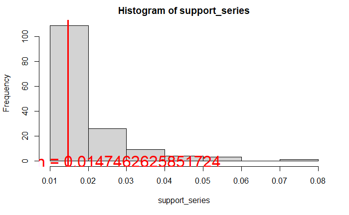

```r
text(x = median(support_series) * 1.7,                 # Add text for median
     y = median(support_series) * 1.7,
     paste("Median =", median(support_series)),
     col = "red",
     cex = 2)
```

```r
confidence_series<-inspect(rules)$confidence
```

|  | lhs |  | rhs | support | confidence | coverage | lift | count |
| --- | --- | --- | --- | --- | --- | --- | --- | --- |
| [1] | {Acer Aspire, ViewSonic Monitor} | => | {HP Laptop} | 0.01078003 | 0.6022727 | 0.01789891 | 3.102225 | 106 |
| [2] | {ASUS 2 Monitor, Lenovo Desktop Computer} | => | {iMac} | 0.01088172 | 0.5911602 | 0.01840740 | 2.307614 | 107 |
| [3] | {Apple Magic Keyboard, Dell Desktop} | => | {iMac} | 0.01016984 | 0.5847953 | 0.01739042 | 2.282768 | 100 |
| [4] | {ASUS Monitor, HP Laptop} | => | {iMac} | 0.01179701 | 0.5829146 | 0.02023797 | 2.275426 | 116 |
| [5] | {ASUS 2 Monitor, HP Laptop} | => | {iMac} | 0.01108512 | 0.5828877 | 0.01901759 | 2.275321 | 109 |
| [6] | {Dell Desktop, ViewSonic Monitor} | => | {HP Laptop} | 0.01525475 | 0.5747126 | 0.02654327 | 2.960267 | 150 |
| [7] | {Dell Desktop, ViewSonic Monitor} | => | {iMac} | 0.01474626 | 0.5555556 | 0.02654327 | 2.168630 | 145 |
| [8] | {Lenovo Desktop Computer, ViewSonic Monitor} | => | {iMac} | 0.01576325 | 0.5555556 | 0.02837384 | 2.168630 | 155 |
| [9] | {HP Laptop, Microsoft Office Home and Student 2016} | => | {iMac} | 0.01291569 | 0.5521739 | 0.02339062 | 2.155429 | 127 |
| [10] | {Acer Desktop, ViewSonic Monitor} | => | {iMac} | 0.01006814 | 0.5439560 | 0.01850910 | 2.123350 | 99 |

[output cut: 142 more lines]

```r
hist(confidence_series)                                   # Draw histogram
abline(v = median(confidence_series),                     # Add line for median
       col = "red",
       lwd = 3)
```

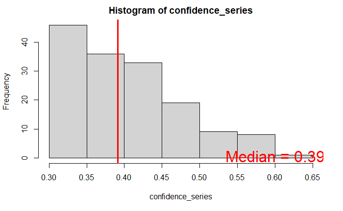

```r
text(x = median(confidence_series) * 1.7,                 # Add text for median
     y = median(confidence_series) * 1.7,
     paste("Median =", median(confidence_series)),
     col = "red",
     cex = 2)
```

```r
library(colorspace) # for sequential_hcl
```

Below, the rules with the Top 10 confidence levels and respective lift (colour) has been plotted.

```r
topRulesConfidence <- rules[1:10]
topRulesSupport <- sort(rules, by = "support")[1:10]
```

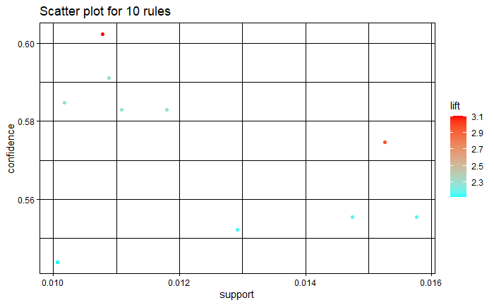

```r
plot(topRulesConfidence, control=list(col=rainbow(2)))
```

[figure not shown]

```r
plot(topRulesSupport, control=list(col=rainbow(2)))
```

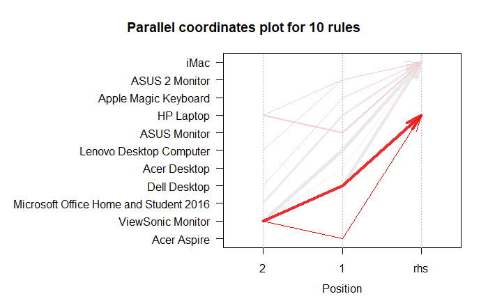

```r
plot(topRulesConfidence, method="paracoord", control=list(reorder=TRUE))
```

[figure not shown]

```r
plot(topRulesSupport, method="paracoord", control=list(reorder=TRUE))
```

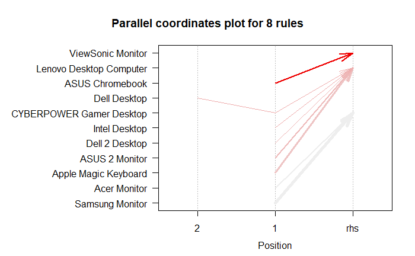

```r
topRulesConfidenceNot <- subset(rules, !items %in% c("HP Laptop","iMac"))[1:8]
topRulesSupportNot <- sort(subset(rules, !items %in% c("HP Laptop","iMac")), by = "support")[1:8]

plot(topRulesConfidenceNot, method="paracoord", control=list(reorder=TRUE))
```

[figure not shown]

```r
plot(topRulesSupportNot, method="paracoord", control=list(reorder=TRUE))
```

```r
NA
NA
```

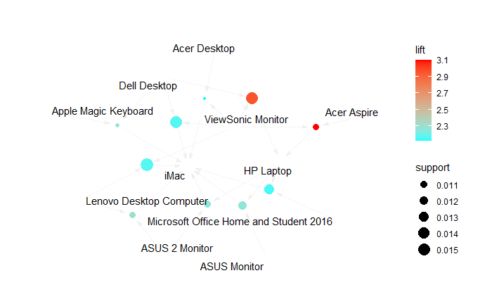

```r
plot(topRulesConfidence, method="graph",control=list(col=rainbow(2)))
```

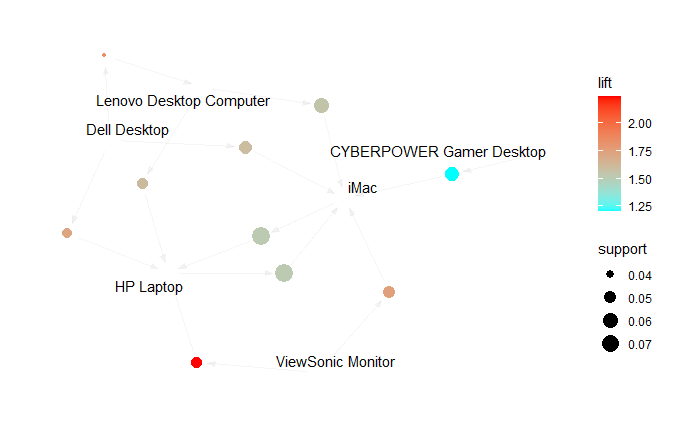

```r
plot(topRulesSupport, method="graph",control=list(col=rainbow(2)))
```

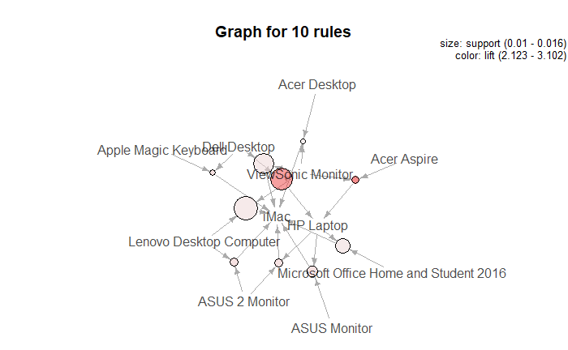

```r
plot(topRulesConfidence, method="graph", control=list(engine = "igraph"))
```

[figure not shown]

```r
plot(topRulesSupport, method="graph", control=list(engine = "igraph"))
```

```r
png(file="GroupedTransactions_TopConfidence.png", width=8, height=6, units="in", res=400)
plot(topRulesConfidence, method = "grouped")
dev.off()
```

```r
png(file="GroupedTransactions_TopSupport.png", width=8, height=6, units="in", res=400)
```

```r
plot(topRulesSupport, method = "grouped")
dev.off()
```